# Building a git workflow - or How I learned to stop worrying about my laptop getting stolen or broken

## Setting up this talk

### My history with git

- Introduced to Git by Coursera’s R for data science course.
- Proceeded to pretend it didn’t exist for 6 years.
- Decided to get back to it in 2019
- Still Learning!

## My progress in Git has been encouraged by these two resources.

[Happy git With R](https://happygitwithr.com/)

[Excuse me, do you have a moment to talk about version control?](https://peerj.com/preprints/3159/)

## What is git?

- why are you doing this to me
- I’m just trying to learn R here
- don’t make me think about file structures and code
- but seriously:

## how do you back up your work?

- what if your laptop goes missing?
- what if you accidentally delete your H:?
- what if you save over code that worked with broken crummy code??
- (https://happygitwithr.com/big-picture.html#big-picture)

## How do you share your work?

- What if you keep doign the same thigns over and over again?
- what if the person after you is going to have to do the same things over and over again
- how do we share code and make it work? In our organization? with collaborators outside?

## My workflow for using Git and Github

- It’s not perfect - and it is a bit clunky to get started with.
- you may want to read through materials and work out your own.

## 1 - go to github and start a new repository

- Github now allows for private repositories for free tier users - ensure that you use private repos.

[figure not shown]

## 2 - copy the link to clone the repo

[figure not shown]

## 3 - clone the repo to my local r folder

- check the ‘Terminal’ to to ensure the folder is going where you want to go
- [Command Line commands!!!](https://swcarpentry.github.io/shell-novice/reference/)
- `cd` is used to navigate through file paths
- `cd ../` will take you up one file layer
- use the following git command:

`git clone linkIjustcopied.git`

[figure not shown]

## 4 - Start a new project, with an existing directory

[figure not shown]

## 5 - make folders to organize my project

- create folders to store your data and other stuff you don’t want/need to track
- with command line:
  - `md data` will create a new folder called ‘data’
  - `mkdir data` will do the same thing
  - i still often just make new folders with windows explorer

## 6 - last step - very important!!

- tell git to ignore certain things
- open .gitignore
- add the files that you want git to not update followed by a ‘/’
- this lets git know that this is a folder you want ignored
- **IF YOU ARE WORKING WITH PI/PHI** - let’s chat more and see how we can ensure privacy policies are adhered to.

[figure not shown]

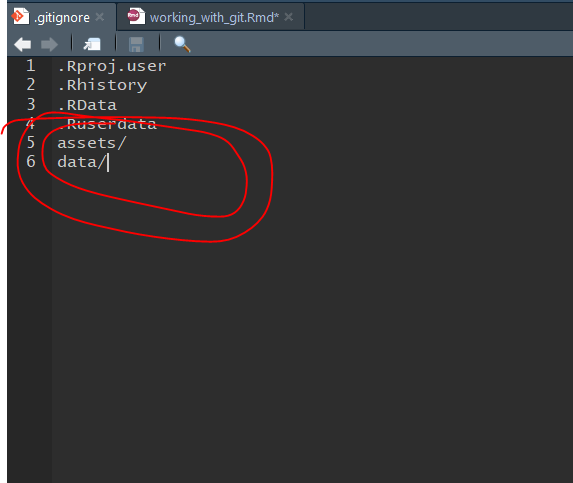

## 7 - Ready to start working!

- Work as I normally do
- when it’s time to save (multiple times a day because i’m paranoid):
  1. `ctrl + s`
  2. Go to terminal and type `git add .`
  3. type `git commit -m "mycommitmessage"` *if you don’t add this you can get into annoying text editors*
  4. type `git push`
  5. Done! i’m in the cloud

## 8 Other workflows exist, and i’m still learning!

- let’s try some together.
- You can also use git locally and not move anything to github.